# Business Intelligence Project

#### Center Data Transform

```r
# BEFORE
summary(STREAMLINING_PROCESSES_AT_KINYANJUI_FARM)
```

```
##       Age          DailyRate      DistanceFromHome   Education
##  Min.   :18.00   Min.   : 102.0   Min.   : 1.000   Min.   :1.000
##  1st Qu.:30.00   1st Qu.: 465.0   1st Qu.: 2.000   1st Qu.:2.000
##  Median :36.00   Median : 802.0   Median : 7.000   Median :3.000
##  Mean   :36.92   Mean   : 802.5   Mean   : 9.193   Mean   :2.913
##  3rd Qu.:43.00   3rd Qu.:1157.0   3rd Qu.:14.000   3rd Qu.:4.000
##  Max.   :60.00   Max.   :1499.0   Max.   :29.000   Max.   :5.000
##  EnvironmentSatisfaction   HourlyRate     JobInvolvement    JobLevel
##  Min.   :1.000           Min.   : 30.00   Min.   :1.00   Min.   :1.000
##  1st Qu.:2.000           1st Qu.: 48.00   1st Qu.:2.00   1st Qu.:1.000
##  Median :3.000           Median : 66.00   Median :3.00   Median :2.000
##  Mean   :2.722           Mean   : 65.89   Mean   :2.73   Mean   :2.064
##  3rd Qu.:4.000           3rd Qu.: 83.75   3rd Qu.:3.00   3rd Qu.:3.000
##  Max.   :4.000           Max.   :100.00   Max.   :4.00   Max.   :5.000
##  JobSatisfaction MonthlyIncome    MonthlyRate    NumCompaniesWorked
##  Min.   :1.000   Min.   : 1009   Min.   : 2094   Min.   :0.000
##  1st Qu.:2.000   1st Qu.: 2911   1st Qu.: 8047   1st Qu.:1.000
##  Median :3.000   Median : 4919   Median :14236   Median :2.000
##  Mean   :2.729   Mean   : 6503   Mean   :14313   Mean   :2.693
##  3rd Qu.:4.000   3rd Qu.: 8379   3rd Qu.:20462   3rd Qu.:4.000
##  Max.   :4.000   Max.   :19999   Max.   :26999   Max.   :9.000
##  PercentSalaryHike PerformanceRating RelationshipSatisfaction StockOptionLevel
##  Min.   :11.00     Min.   :3.000     Min.   :1.000            Min.   :0.0000
##  1st Qu.:12.00     1st Qu.:3.000     1st Qu.:2.000            1st Qu.:0.0000
##  Median :14.00     Median :3.000     Median :3.000            Median :1.0000
##  Mean   :15.21     Mean   :3.154     Mean   :2.712            Mean   :0.7939
##  3rd Qu.:18.00     3rd Qu.:3.000     3rd Qu.:4.000            3rd Qu.:1.0000
##  Max.   :25.00     Max.   :4.000     Max.   :4.000            Max.   :3.0000
##  TotalWorkingYears TrainingTimesLastYear WorkLifeBalance YearsAtCompany
##  Min.   : 0.00     Min.   :0.000         Min.   :1.000   Min.   : 0.000
##  1st Qu.: 6.00     1st Qu.:2.000         1st Qu.:2.000   1st Qu.: 3.000
##  Median :10.00     Median :3.000         Median :3.000   Median : 5.000
##  Mean   :11.28     Mean   :2.799         Mean   :2.761   Mean   : 7.008
##  3rd Qu.:15.00     3rd Qu.:3.000         3rd Qu.:3.000   3rd Qu.: 9.000
##  Max.   :40.00     Max.   :6.000         Max.   :4.000   Max.   :40.000
##  YearsInCurrentRole YearsSinceLastPromotion YearsWithCurrManager
##  Min.   : 0.000     Min.   : 0.000          Min.   : 0.000
##  1st Qu.: 2.000     1st Qu.: 0.000          1st Qu.: 2.000
##  Median : 3.000     Median : 1.000          Median : 3.000
##  Mean   : 4.229     Mean   : 2.188          Mean   : 4.123
##  3rd Qu.: 7.000     3rd Qu.: 3.000          3rd Qu.: 7.000
##  Max.   :18.000     Max.   :15.000          Max.   :17.000
```

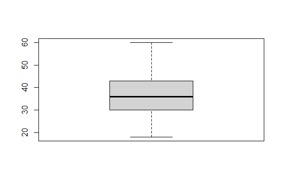

```r
boxplot(STREAMLINING_PROCESSES_AT_KINYANJUI_FARM[, 1], main = names(STREAMLINING_PROCESSES_AT_KINYANJUI_FARM)[1])
```

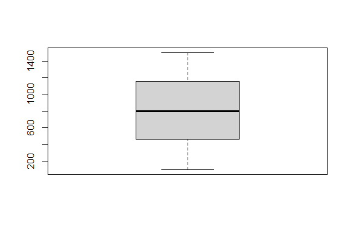

```r
boxplot(STREAMLINING_PROCESSES_AT_KINYANJUI_FARM[, 2], main = names(STREAMLINING_PROCESSES_AT_KINYANJUI_FARM)[2])
```

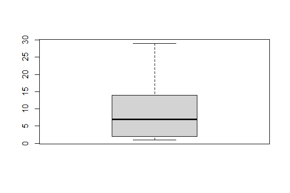

```r
boxplot(STREAMLINING_PROCESSES_AT_KINYANJUI_FARM[, 3], main = names(STREAMLINING_PROCESSES_AT_KINYANJUI_FARM)[3])
```

```r
boxplot(STREAMLINING_PROCESSES_AT_KINYANJUI_FARM[, 5], main = names(STREAMLINING_PROCESSES_AT_KINYANJUI_FARM)[5])
```

[output not shown]

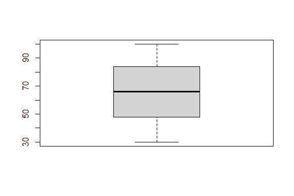

```r
boxplot(STREAMLINING_PROCESSES_AT_KINYANJUI_FARM[, 6], main = names(STREAMLINING_PROCESSES_AT_KINYANJUI_FARM)[6])
```

```r
boxplot(STREAMLINING_PROCESSES_AT_KINYANJUI_FARM[, 7], main = names(STREAMLINING_PROCESSES_AT_KINYANJUI_FARM)[7])
```

[output not shown]

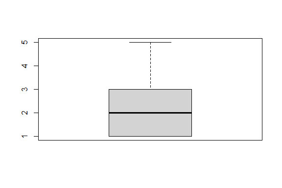

```r
boxplot(STREAMLINING_PROCESSES_AT_KINYANJUI_FARM[, 8], main = names(STREAMLINING_PROCESSES_AT_KINYANJUI_FARM)[8])
```

```r
boxplot(STREAMLINING_PROCESSES_AT_KINYANJUI_FARM[, 9], main = names(STREAMLINING_PROCESSES_AT_KINYANJUI_FARM)[9])
```

[output not shown]

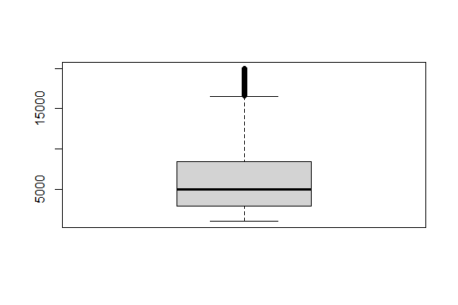

```r
boxplot(STREAMLINING_PROCESSES_AT_KINYANJUI_FARM[, 10], main = names(STREAMLINING_PROCESSES_AT_KINYANJUI_FARM)[10])
```

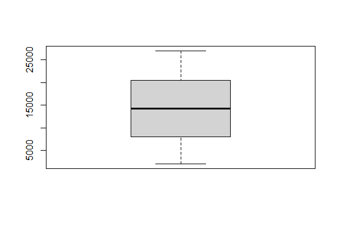

```r
boxplot(STREAMLINING_PROCESSES_AT_KINYANJUI_FARM[, 11], main = names(STREAMLINING_PROCESSES_AT_KINYANJUI_FARM)[11])
```

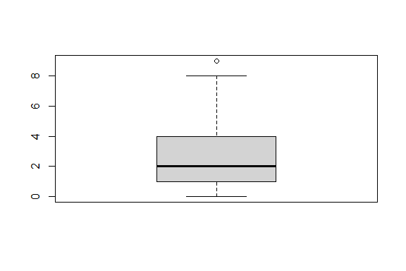

```r
boxplot(STREAMLINING_PROCESSES_AT_KINYANJUI_FARM[, 12], main = names(STREAMLINING_PROCESSES_AT_KINYANJUI_FARM)[12])
```

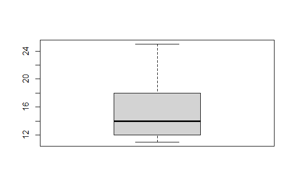

```r
boxplot(STREAMLINING_PROCESSES_AT_KINYANJUI_FARM[, 13], main = names(STREAMLINING_PROCESSES_AT_KINYANJUI_FARM)[13])
```

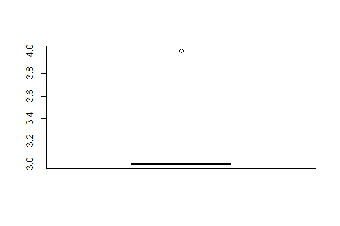

```r
boxplot(STREAMLINING_PROCESSES_AT_KINYANJUI_FARM[, 14], main = names(STREAMLINING_PROCESSES_AT_KINYANJUI_FARM)[14])
```

```r
model_of_the_transform <- preProcess(STREAMLINING_PROCESSES_AT_KINYANJUI_FARM, method = c("center"))
print(model_of_the_transform)
```

```
## Created from 1470 samples and 23 variables
##
## Pre-processing:
##   - centered (23)
##   - ignored (0)
```

```r
streamling_processes_center_transform <- predict(model_of_the_transform, # nolint
                                           STREAMLINING_PROCESSES_AT_KINYANJUI_FARM)

# AFTER

summary(streamling_processes_center_transform)
```

```
##       Age             DailyRate         DistanceFromHome   Education
##  Min.   :-18.9238   Min.   :-700.4857   Min.   :-8.193   Min.   :-1.91293
##  1st Qu.: -6.9238   1st Qu.:-337.4857   1st Qu.:-7.193   1st Qu.:-0.91293
##  Median : -0.9238   Median :  -0.4857   Median :-2.193   Median : 0.08707
##  Mean   :  0.0000   Mean   :   0.0000   Mean   : 0.000   Mean   : 0.00000
##  3rd Qu.:  6.0762   3rd Qu.: 354.5143   3rd Qu.: 4.807   3rd Qu.: 1.08707
##  Max.   : 23.0762   Max.   : 696.5143   Max.   :19.807   Max.   : 2.08707
##  EnvironmentSatisfaction   HourlyRate       JobInvolvement
##  Min.   :-1.7218         Min.   :-35.8912   Min.   :-1.7299
##  1st Qu.:-0.7218         1st Qu.:-17.8912   1st Qu.:-0.7299
##  Median : 0.2782         Median :  0.1088   Median : 0.2701
##  Mean   : 0.0000         Mean   :  0.0000   Mean   : 0.0000
##  3rd Qu.: 1.2782         3rd Qu.: 17.8588   3rd Qu.: 0.2701
##  Max.   : 1.2782         Max.   : 34.1088   Max.   : 1.2701
##     JobLevel        JobSatisfaction   MonthlyIncome    MonthlyRate
##  Min.   :-1.06395   Min.   :-1.7286   Min.   :-5494   Min.   :-12219.1
##  1st Qu.:-1.06395   1st Qu.:-0.7286   1st Qu.:-3592   1st Qu.: -6266.1
##  Median :-0.06395   Median : 0.2714   Median :-1584   Median :   -77.6
##  Mean   : 0.00000   Mean   : 0.0000   Mean   :    0   Mean   :     0.0
##  3rd Qu.: 0.93605   3rd Qu.: 1.2714   3rd Qu.: 1876   3rd Qu.:  6148.4
##  Max.   : 2.93605   Max.   : 1.2714   Max.   :13496   Max.   : 12685.9
##  NumCompaniesWorked PercentSalaryHike PerformanceRating
##  Min.   :-2.6932    Min.   :-4.21     Min.   :-0.1537
##  1st Qu.:-1.6932    1st Qu.:-3.21     1st Qu.:-0.1537
##  Median :-0.6932    Median :-1.21     Median :-0.1537
##  Mean   : 0.0000    Mean   : 0.00     Mean   : 0.0000
##  3rd Qu.: 1.3068    3rd Qu.: 2.79     3rd Qu.:-0.1537
##  Max.   : 6.3068    Max.   : 9.79     Max.   : 0.8463
##  RelationshipSatisfaction StockOptionLevel  TotalWorkingYears
##  Min.   :-1.7122          Min.   :-0.7939   Min.   :-11.28
##  1st Qu.:-0.7122          1st Qu.:-0.7939   1st Qu.: -5.28
##  Median : 0.2878          Median : 0.2061   Median : -1.28
##  Mean   : 0.0000          Mean   : 0.0000   Mean   :  0.00
##  3rd Qu.: 1.2878          3rd Qu.: 0.2061   3rd Qu.:  3.72
##  Max.   : 1.2878          Max.   : 2.2061   Max.   : 28.72
##  TrainingTimesLastYear WorkLifeBalance   YearsAtCompany   YearsInCurrentRole
##  Min.   :-2.7993       Min.   :-1.7612   Min.   :-7.008   Min.   :-4.229
##  1st Qu.:-0.7993       1st Qu.:-0.7612   1st Qu.:-4.008   1st Qu.:-2.229
##  Median : 0.2007       Median : 0.2388   Median :-2.008   Median :-1.229
##  Mean   : 0.0000       Mean   : 0.0000   Mean   : 0.000   Mean   : 0.000
##  3rd Qu.: 0.2007       3rd Qu.: 0.2388   3rd Qu.: 1.992   3rd Qu.: 2.771
##  Max.   : 3.2007       Max.   : 1.2388   Max.   :32.992   Max.   :13.771
##  YearsSinceLastPromotion YearsWithCurrManager
##  Min.   :-2.1878         Min.   :-4.123
##  1st Qu.:-2.1878         1st Qu.:-2.123
##  Median :-1.1878         Median :-1.123
##  Mean   : 0.0000         Mean   : 0.000
##  3rd Qu.: 0.8122         3rd Qu.: 2.877
##  Max.   :12.8122         Max.   :12.877
```

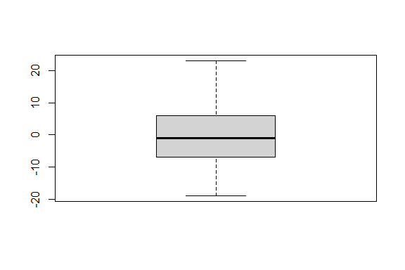

```r
boxplot(streamling_processes_center_transform[, 1], main = names(streamling_processes_center_transform)[1])
```

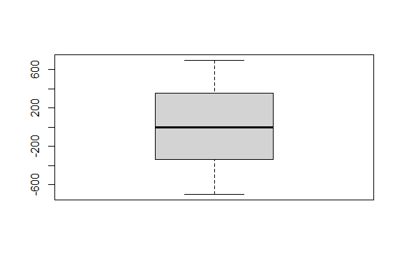

```r
boxplot(streamling_processes_center_transform[, 2], main = names(streamling_processes_center_transform)[2])
```

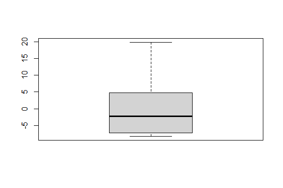

```r
boxplot(streamling_processes_center_transform[, 3], main = names(streamling_processes_center_transform)[3])
```

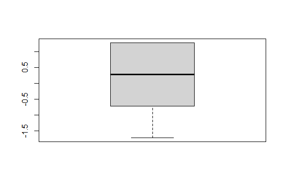

```r
boxplot(streamling_processes_center_transform[, 5], main = names(streamling_processes_center_transform)[5])
```

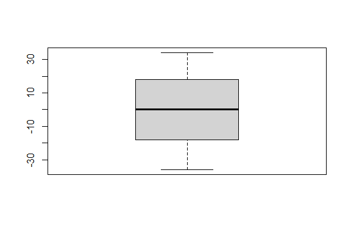

```r
boxplot(streamling_processes_center_transform[, 6], main = names(streamling_processes_center_transform)[6])
```

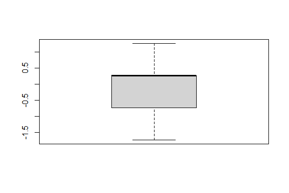

```r
boxplot(streamling_processes_center_transform[, 7], main = names(streamling_processes_center_transform)[7])
```

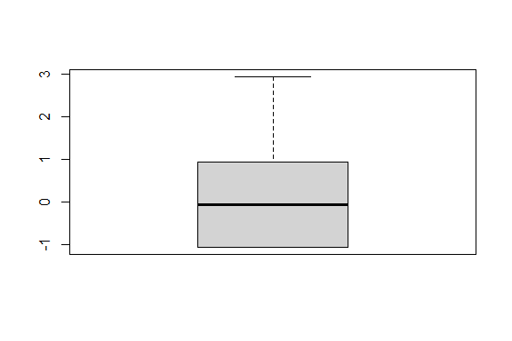

```r
boxplot(streamling_processes_center_transform[, 8], main = names(streamling_processes_center_transform)[8])
```

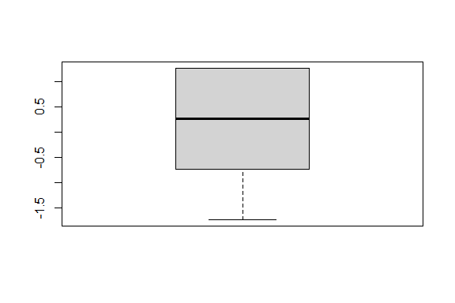

```r
boxplot(streamling_processes_center_transform[, 9], main = names(streamling_processes_center_transform)[9])
```

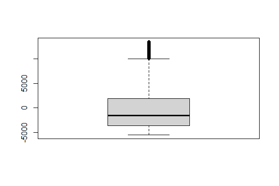

```r
boxplot(streamling_processes_center_transform[, 10], main = names(streamling_processes_center_transform)[10])
```

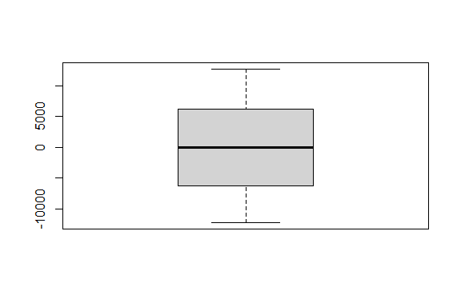

```r
boxplot(streamling_processes_center_transform[, 11], main = names(streamling_processes_center_transform)[11])
```

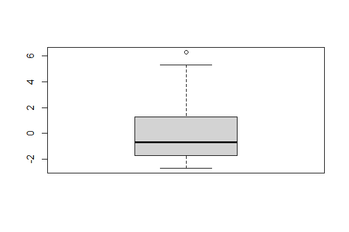

```r
boxplot(streamling_processes_center_transform[, 12], main = names(streamling_processes_center_transform)[12])
```

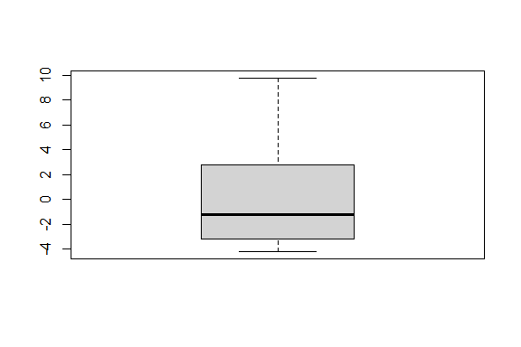

```r
boxplot(streamling_processes_center_transform[, 13], main = names(streamling_processes_center_transform)[13])
```

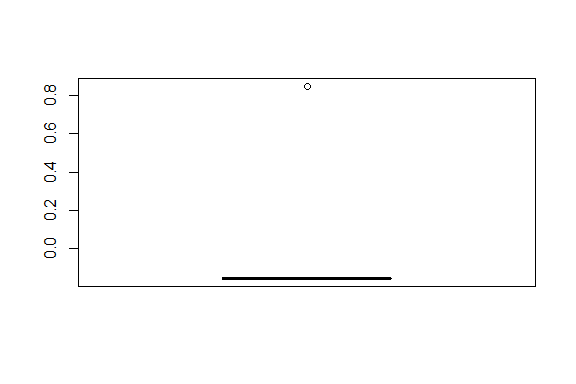

```r
boxplot(streamling_processes_center_transform[, 14], main = names(streamling_processes_center_transform)[14])
```

#### Standardize Data Transform to have a std of 1

```r
### The Standardize Basic Transform on the Boston Housing Dataset ----
# BEFORE

library(readr)
STREAMLINING_PROCESSES_AT_KINYANJUI_FARM <- read_csv("data/STREAMLINING PROCESSES AT KINYANJUI FARM.csv")
# Drop specified columns
columns_to_drop <- c('EmployeeCount', 'EmployeeNumber', 'Over18', 'StandardHours')
STREAMLINING_PROCESSES_AT_KINYANJUI_FARM <- STREAMLINING_PROCESSES_AT_KINYANJUI_FARM[, !(names(STREAMLINING_PROCESSES_AT_KINYANJUI_FARM) %in% columns_to_drop)]
summary(STREAMLINING_PROCESSES_AT_KINYANJUI_FARM)
```

```
##       Age         Attrition         BusinessTravel       DailyRate
##  Min.   :18.00   Length:1470        Length:1470        Min.   : 102.0
##  1st Qu.:30.00   Class :character   Class :character   1st Qu.: 465.0
##  Median :36.00   Mode  :character   Mode  :character   Median : 802.0
##  Mean   :36.92                                         Mean   : 802.5
##  3rd Qu.:43.00                                         3rd Qu.:1157.0
##  Max.   :60.00                                         Max.   :1499.0
##   Department        DistanceFromHome   Education     EducationField
##  Length:1470        Min.   : 1.000   Min.   :1.000   Length:1470
##  Class :character   1st Qu.: 2.000   1st Qu.:2.000   Class :character
##  Mode  :character   Median : 7.000   Median :3.000   Mode  :character
##                     Mean   : 9.193   Mean   :2.913
##                     3rd Qu.:14.000   3rd Qu.:4.000
##                     Max.   :29.000   Max.   :5.000
##  EnvironmentSatisfaction    Gender            HourlyRate     JobInvolvement
##  Min.   :1.000           Length:1470        Min.   : 30.00   Min.   :1.00
##  1st Qu.:2.000           Class :character   1st Qu.: 48.00   1st Qu.:2.00
##  Median :3.000           Mode  :character   Median : 66.00   Median :3.00
##  Mean   :2.722                              Mean   : 65.89   Mean   :2.73
##  3rd Qu.:4.000                              3rd Qu.: 83.75   3rd Qu.:3.00
##  Max.   :4.000                              Max.   :100.00   Max.   :4.00
##     JobLevel       JobRole          JobSatisfaction MaritalStatus
##  Min.   :1.000   Length:1470        Min.   :1.000   Length:1470
##  1st Qu.:1.000   Class :character   1st Qu.:2.000   Class :character
##  Median :2.000   Mode  :character   Median :3.000   Mode  :character
##  Mean   :2.064                      Mean   :2.729
##  3rd Qu.:3.000                      3rd Qu.:4.000
##  Max.   :5.000                      Max.   :4.000
##  MonthlyIncome    MonthlyRate    NumCompaniesWorked   OverTime
##  Min.   : 1009   Min.   : 2094   Min.   :0.000      Length:1470
##  1st Qu.: 2911   1st Qu.: 8047   1st Qu.:1.000      Class :character
##  Median : 4919   Median :14236   Median :2.000      Mode  :character
##  Mean   : 6503   Mean   :14313   Mean   :2.693
##  3rd Qu.: 8379   3rd Qu.:20462   3rd Qu.:4.000
##  Max.   :19999   Max.   :26999   Max.   :9.000
##  PercentSalaryHike PerformanceRating RelationshipSatisfaction StockOptionLevel
##  Min.   :11.00     Min.   :3.000     Min.   :1.000            Min.   :0.0000
##  1st Qu.:12.00     1st Qu.:3.000     1st Qu.:2.000            1st Qu.:0.0000
##  Median :14.00     Median :3.000     Median :3.000            Median :1.0000
##  Mean   :15.21     Mean   :3.154     Mean   :2.712            Mean   :0.7939
##  3rd Qu.:18.00     3rd Qu.:3.000     3rd Qu.:4.000            3rd Qu.:1.0000
##  Max.   :25.00     Max.   :4.000     Max.   :4.000            Max.   :3.0000
##  TotalWorkingYears TrainingTimesLastYear WorkLifeBalance YearsAtCompany
##  Min.   : 0.00     Min.   :0.000         Min.   :1.000   Min.   : 0.000
##  1st Qu.: 6.00     1st Qu.:2.000         1st Qu.:2.000   1st Qu.: 3.000
##  Median :10.00     Median :3.000         Median :3.000   Median : 5.000
##  Mean   :11.28     Mean   :2.799         Mean   :2.761   Mean   : 7.008
##  3rd Qu.:15.00     3rd Qu.:3.000         3rd Qu.:3.000   3rd Qu.: 9.000
##  Max.   :40.00     Max.   :6.000         Max.   :4.000   Max.   :40.000
##  YearsInCurrentRole YearsSinceLastPromotion YearsWithCurrManager
##  Min.   : 0.000     Min.   : 0.000          Min.   : 0.000
##  1st Qu.: 2.000     1st Qu.: 0.000          1st Qu.: 2.000
##  Median : 3.000     Median : 1.000          Median : 3.000
##  Mean   : 4.229     Mean   : 2.188          Mean   : 4.123
##  3rd Qu.: 7.000     3rd Qu.: 3.000          3rd Qu.: 7.000
##  Max.   :18.000     Max.   :15.000          Max.   :17.000
```

```r
sapply(STREAMLINING_PROCESSES_AT_KINYANJUI_FARM[, c(1,4, 6, 7, 9, 11, 12, 13, 15 , 17 , 18, 19,  21, 22, 23,24, 25, 26, 27, 28 ,29, 30, 31   )], sd)
```

```
##                      Age                DailyRate         DistanceFromHome
##                9.1353735              403.5090999                8.1068644
##                Education  EnvironmentSatisfaction               HourlyRate
##                1.0241649                1.0930822               20.3294276
##           JobInvolvement                 JobLevel          JobSatisfaction
##                0.7115611                1.1069399                1.1028461
##            MonthlyIncome              MonthlyRate       NumCompaniesWorked
##             4707.9567831             7117.7860441                2.4980090
##        PercentSalaryHike        PerformanceRating RelationshipSatisfaction
##                3.6599377                0.3608235                1.0812089
##         StockOptionLevel        TotalWorkingYears    TrainingTimesLastYear
##                0.8520767                7.7807817                1.2892706
##          WorkLifeBalance           YearsAtCompany       YearsInCurrentRole
##                0.7064758                6.1265252                3.6231370
##  YearsSinceLastPromotion     YearsWithCurrManager
##                3.2224303                3.5681361
```

```r
model_of_the_transform <- preProcess(STREAMLINING_PROCESSES_AT_KINYANJUI_FARM,
                                     method = c("scale", "center"))
print(model_of_the_transform)
```

```
## Created from 1470 samples and 31 variables
##
## Pre-processing:
##   - centered (23)
##   - ignored (8)
##   - scaled (23)
```

```r
streamling_processes_standardize_transform <- predict(model_of_the_transform, # nolint
                                                STREAMLINING_PROCESSES_AT_KINYANJUI_FARM)

# AFTER
summary(streamling_processes_standardize_transform)
```

```
##       Age           Attrition         BusinessTravel       DailyRate
##  Min.   :-2.0715   Length:1470        Length:1470        Min.   :-1.735985
##  1st Qu.:-0.7579   Class :character   Class :character   1st Qu.:-0.836377
##  Median :-0.1011   Mode  :character   Mode  :character   Median :-0.001204
##  Mean   : 0.0000                                         Mean   : 0.000000
##  3rd Qu.: 0.6651                                         3rd Qu.: 0.878578
##  Max.   : 2.5260                                         Max.   : 1.726143
##   Department        DistanceFromHome    Education        EducationField
##  Length:1470        Min.   :-1.0106   Min.   :-1.86779   Length:1470
##  Class :character   1st Qu.:-0.8872   1st Qu.:-0.89138   Class :character
##  Mode  :character   Median :-0.2705   Median : 0.08502   Mode  :character
##                     Mean   : 0.0000   Mean   : 0.00000
##                     3rd Qu.: 0.5930   3rd Qu.: 1.06143
##                     Max.   : 2.4433   Max.   : 2.03783
##  EnvironmentSatisfaction    Gender            HourlyRate
##  Min.   :-1.5752         Length:1470        Min.   :-1.765478
##  1st Qu.:-0.6603         Class :character   1st Qu.:-0.880062
##  Median : 0.2545         Mode  :character   Median : 0.005354
##  Mean   : 0.0000                            Mean   : 0.000000
##  3rd Qu.: 1.1694                            3rd Qu.: 0.878472
##  Max.   : 1.1694                            Max.   : 1.677806
##  JobInvolvement       JobLevel          JobRole          JobSatisfaction
##  Min.   :-2.4312   Min.   :-0.96116   Length:1470        Min.   :-1.5674
##  1st Qu.:-1.0258   1st Qu.:-0.96116   Class :character   1st Qu.:-0.6606
##  Median : 0.3795   Median :-0.05777   Mode  :character   Median : 0.2461
##  Mean   : 0.0000   Mean   : 0.00000                      Mean   : 0.0000
##  3rd Qu.: 0.3795   3rd Qu.: 0.84562                      3rd Qu.: 1.1529
##  Max.   : 1.7849   Max.   : 2.65241                      Max.   : 1.1529
##  MaritalStatus      MonthlyIncome      MonthlyRate      NumCompaniesWorked
##  Length:1470        Min.   :-1.1669   Min.   :-1.7167   Min.   :-1.0781
##  Class :character   1st Qu.:-0.7629   1st Qu.:-0.8803   1st Qu.:-0.6778
##  Mode  :character   Median :-0.3364   Median :-0.0109   Median :-0.2775
##                     Mean   : 0.0000   Mean   : 0.0000   Mean   : 0.0000
##                     3rd Qu.: 0.3985   3rd Qu.: 0.8638   3rd Qu.: 0.5231
##                     Max.   : 2.8667   Max.   : 1.7823   Max.   : 2.5247
##    OverTime         PercentSalaryHike PerformanceRating
##  Length:1470        Min.   :-1.1502   Min.   :-0.4261
##  Class :character   1st Qu.:-0.8769   1st Qu.:-0.4261
##  Mode  :character   Median :-0.3305   Median :-0.4261
##                     Mean   : 0.0000   Mean   : 0.0000
```

[output cut: 8 more lines]

```
##  Max.   : 1.1910          Max.   : 2.5891   Max.   : 3.6912
##  TrainingTimesLastYear WorkLifeBalance  YearsAtCompany    YearsInCurrentRole
##  Min.   :-2.1712       Min.   :-2.493   Min.   :-1.1439   Min.   :-1.1673
##  1st Qu.:-0.6200       1st Qu.:-1.077   1st Qu.:-0.6542   1st Qu.:-0.6153
##  Median : 0.1557       Median : 0.338   Median :-0.3278   Median :-0.3393
##  Mean   : 0.0000       Mean   : 0.000   Mean   : 0.0000   Mean   : 0.0000
##  3rd Qu.: 0.1557       3rd Qu.: 0.338   3rd Qu.: 0.3251   3rd Qu.: 0.7647
##  Max.   : 2.4826       Max.   : 1.753   Max.   : 5.3851   Max.   : 3.8008
##  YearsSinceLastPromotion YearsWithCurrManager
##  Min.   :-0.6789         Min.   :-1.1555
##  1st Qu.:-0.6789         1st Qu.:-0.5950
##  Median :-0.3686         Median :-0.3148
##  Mean   : 0.0000         Mean   : 0.0000
##  3rd Qu.: 0.2521         3rd Qu.: 0.8063
##  Max.   : 3.9760         Max.   : 3.6089
```

```r
sapply(streamling_processes_standardize_transform[, c(1,4, 6, 7, 9, 11, 12, 13, 15 , 17 , 18, 19,  21, 22, 23,24, 25, 26, 27, 28 ,29, 30, 31   )], sd)
```

```
##                      Age                DailyRate         DistanceFromHome
##                        1                        1                        1
##                Education  EnvironmentSatisfaction               HourlyRate
##                        1                        1                        1
##           JobInvolvement                 JobLevel          JobSatisfaction
##                        1                        1                        1
##            MonthlyIncome              MonthlyRate       NumCompaniesWorked
##                        1                        1                        1
##        PercentSalaryHike        PerformanceRating RelationshipSatisfaction
##                        1                        1                        1
##         StockOptionLevel        TotalWorkingYears    TrainingTimesLastYear
##                        1                        1                        1
##          WorkLifeBalance           YearsAtCompany       YearsInCurrentRole
##                        1                        1                        1
##  YearsSinceLastPromotion     YearsWithCurrManager
##                        1                        1
```

# Training Models

`Training Models` refers to the process of building and refining predictive or descriptive models using machine learning algorithms. In this context, “training” involves using a labeled dataset (input data paired with corresponding output labels) to teach the model to make predictions or classifications. The model learns patterns and relationships within the training data, adjusting its internal parameters to optimize its performance. The trained model can then be evaluated on new, unseen data to assess its generalization ability. The goal is to develop a model that accurately captures underlying patterns in the data and can make reliable predictions on new, similar data. Techniques for training models include regression, classification, clustering, and neural networks, among others.

### Split the dataset

```r
## 1. Split the dataset
train_index <- createDataPartition(STREAMLINING_PROCESSES_AT_KINYANJUI_FARM$Attrition,
                                   p = 0.75,
                                   list = FALSE)
train_streamling_processes_train <- STREAMLINING_PROCESSES_AT_KINYANJUI_FARM[train_index, ]
test_streamling_processes_test <- STREAMLINING_PROCESSES_AT_KINYANJUI_FARM[-train_index, ]

# Check the column names of pima_train
colnames(train_streamling_processes_train)
```

```
##  [1] "Age"                      "Attrition"
##  [3] "BusinessTravel"           "DailyRate"
##  [5] "Department"               "DistanceFromHome"
##  [7] "Education"                "EducationField"
##  [9] "EnvironmentSatisfaction"  "Gender"
## [11] "HourlyRate"               "JobInvolvement"
## [13] "JobLevel"                 "JobRole"
## [15] "JobSatisfaction"          "MaritalStatus"
## [17] "MonthlyIncome"            "MonthlyRate"
## [19] "NumCompaniesWorked"       "OverTime"
## [21] "PercentSalaryHike"        "PerformanceRating"
## [23] "RelationshipSatisfaction" "StockOptionLevel"
## [25] "TotalWorkingYears"        "TrainingTimesLastYear"
## [27] "WorkLifeBalance"          "YearsAtCompany"
## [29] "YearsInCurrentRole"       "YearsSinceLastPromotion"
## [31] "YearsWithCurrManager"
```

### NaiveBayes() function in the e1071 package

```r
# Train the Naive Bayes model
e107_streamling_processes_dataset_model_nb_e1071 <-
  e1071::naiveBayes(Attrition ~ .,
                    data = train_streamling_processes_train)

# Testing
predictions_nb_e1071 <-
  predict(e107_streamling_processes_dataset_model_nb_e1071,
          test_streamling_processes_test[, 1:31])

# Check unique levels
unique_levels_pred <- levels(predictions_nb_e1071)
unique_levels_actual <- levels(test_streamling_processes_test$Attrition)

# Compare levels
setdiff(unique_levels_pred, unique_levels_actual)
```

```
## [1] "No"  "Yes"
```

```r
setdiff(unique_levels_actual, unique_levels_pred)
```

[output not shown]

```r
# Convert predictions to factor and align levels
predictions_nb_e1071 <- as.factor(predictions_nb_e1071)
#levels(predictions_nb_e1071) <- levels(test_streamling_processes_test$Attrition)

#Update Actual Levels to Match Predicted Levels
test_streamling_processes_test$Attrition <- as.factor(test_streamling_processes_test$Attrition)
levels(test_streamling_processes_test$Attrition) <- levels(predictions_nb_e1071)


# View the Results
print(predictions_nb_e1071)
```

```
##   [1] Yes No  No  No  Yes No  Yes Yes No  Yes No  Yes No  Yes No  No  No  No
##  [19] No  No  No  Yes No  No  No  No  No  No  No  No  No  No  No  No  Yes No
##  [37] No  No  No  Yes No  No  No  No  No  No  No  No  No  No  No  No  Yes No
##  [55] No  No  No  No  No  No  Yes No  No  No  No  No  No  No  No  Yes No  No
##  [73] No  No  No  No  No  Yes No  Yes No  Yes Yes No  No  No  No  No  No  No
##  [91] Yes Yes No  Yes Yes No  No  No  No  No  No  No  No  No  Yes No  Yes No
## [109] No  Yes No  No  No  No  No  Yes No  Yes Yes No  No  No  No  Yes No  No
## [127] No  No  No  No  Yes Yes No  No  No  Yes No  No  No  No  No  No  No  No
## [145] Yes Yes No  No  No  No  Yes Yes No  Yes Yes No  No  No  No  No  Yes No
## [163] Yes No  No  No  Yes No  No  No  Yes No  Yes No  No  No  Yes No  No  No
## [181] No  Yes Yes No  No  No  No  No  No  Yes No  Yes No  No  Yes No  No  No
## [199] No  No  Yes No  Yes No  No  Yes No  Yes No  No  No  No  No  No  No  No
## [217] No  No  No  No  No  No  No  Yes No  No  No  No  No  Yes No  No  No  No
## [235] No  No  Yes No  No  No  No  No  No  No  Yes No  No  No  No  No  No  No
## [253] No  Yes No  No  No  No  Yes No  No  Yes No  No  No  No  No  No  No  Yes
## [271] Yes Yes No  No  No  No  No  No  No  No  No  No  Yes No  No  No  Yes No
## [289] Yes No  No  No  Yes No  Yes No  No  No  No  No  Yes No  No  Yes No  No
## [307] No  No  Yes No  Yes No  No  No  No  No  No  No  No  No  No  No  Yes No
## [325] No  No  No  No  Yes No  Yes No  Yes No  No  No  No  No  No  No  No  Yes
## [343] No  Yes No  No  No  No  No  No  No  No  No  Yes Yes No  Yes No  No  Yes
## [361] No  No  No  No  Yes No  No
## Levels: No Yes
```

```r
# Confusion Matrix
conf_matrix <- caret::confusionMatrix(predictions_nb_e1071,
                                      test_streamling_processes_test$Attrition)
print(conf_matrix)
```

```
## Confusion Matrix and Statistics
##
##           Reference
## Prediction  No Yes
##        No  261  24
##        Yes  47  35
##
##                Accuracy : 0.8065
##                  95% CI : (0.7624, 0.8457)
##     No Information Rate : 0.8392
##     P-Value [Acc > NIR] : 0.95954
##
##                   Kappa : 0.3806
##
##  Mcnemar's Test P-Value : 0.00903
##
##             Sensitivity : 0.8474
##             Specificity : 0.5932
##          Pos Pred Value : 0.9158
##          Neg Pred Value : 0.4268
##              Prevalence : 0.8392
##          Detection Rate : 0.7112
##    Detection Prevalence : 0.7766
##       Balanced Accuracy : 0.7203
##
##        'Positive' Class : No
##
```

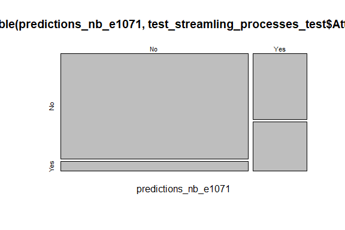

```r
# The confusion matrix can also be viewed graphically,
# although with less information.
plot(table(predictions_nb_e1071,
           test_streamling_processes_test$`Attrition`))
```

```r
### Bootstrapping train control

#train_control <- trainControl(method = "boot", number = 10000)

#streamling_processes_dataset_model_lm <- caret::train(`MonthlyIncome` ~`Attrition` ,
    #                                  data = train_streamling_processes_train,
    #                                  trControl = train_control,
    #                                  method = "lm",
    #                                  metric = "RMSE")


### Test the trained linear regression model using the testing dataset
#predictions_lm <- predict(streamling_processes_dataset_model_lm,
 #                         test_streamling_processes_test[, 1:31])

### View the RMSE and the predicted values for the 9 observations
#print(streamling_processes_dataset_model_lm)
#print(predictions_lm)
```

#### Classification: LDA with k-fold Cross Validation

```r
### LDA Attritionifier based on a 5-fold cross validation
train_control_lda <- trainControl(method = "cv", number = 5)

streamling_dateset_model_lda <-
  caret::train(`Attrition` ~ ., data = STREAMLINING_PROCESSES_AT_KINYANJUI_FARM,
               trControl = train_control_lda, na.action = na.omit, method = "lda2",
               metric = "Accuracy")

### 3.b. Test the trained LDA model using the testing dataset
predictions_lda <- predict(streamling_dateset_model_lda,
                           test_streamling_processes_test[, 1:31])

### 3.c. View the summary of the model and view the confusion matrix
print(streamling_dateset_model_lda)
```

```
## Linear Discriminant Analysis
##
## 1470 samples
##   30 predictor
##    2 classes: 'No', 'Yes'
##
## No pre-processing
## Resampling: Cross-Validated (5 fold)
## Summary of sample sizes: 1176, 1175, 1177, 1175, 1177
## Resampling results:
##
##   Accuracy   Kappa
##   0.8734775  0.436173
##
## Tuning parameter 'dimen' was held constant at a value of 1
```

```r
caret::confusionMatrix(predictions_lda, test_streamling_processes_test$Attrition)
```

```
## Confusion Matrix and Statistics
##
##           Reference
## Prediction  No Yes
##        No  298  31
##        Yes  10  28
##
##                Accuracy : 0.8883
##                  95% CI : (0.8515, 0.9186)
##     No Information Rate : 0.8392
##     P-Value [Acc > NIR] : 0.004869
##
##                   Kappa : 0.5164
##
##  Mcnemar's Test P-Value : 0.001787
##
##             Sensitivity : 0.9675
##             Specificity : 0.4746
##          Pos Pred Value : 0.9058
##          Neg Pred Value : 0.7368
##              Prevalence : 0.8392
##          Detection Rate : 0.8120
##    Detection Prevalence : 0.8965
##       Balanced Accuracy : 0.7211
##
##        'Positive' Class : No
##
```

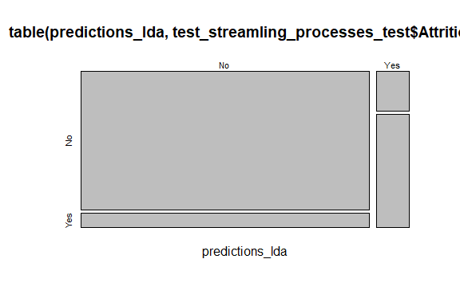

```r
plot(table(predictions_lda, test_streamling_processes_test$Attrition))
```

```r
### 4.a. Train an e1071::naive Bayes Attritionifier based on the churn variable
streamling_dateset_model_nb <-
  e1071::naiveBayes(`Attrition` ~ ., data = train_streamling_processes_train)

### 4.b. Test the trained naive Bayes Attritionifier using the testing dataset
predictions_nb_e1071 <-
  predict(streamling_dateset_model_nb, test_streamling_processes_test[, 1:31])

### 4.c. View a summary of the naive Bayes model and the confusion matrix
print(streamling_dateset_model_nb)
```

```
##
## Naive Bayes Classifier for Discrete Predictors
##
## Call:
## naiveBayes.default(x = X, y = Y, laplace = laplace)
##
## A-priori probabilities:
## Y
##        No       Yes
## 0.8386219 0.1613781
##
## Conditional probabilities:
##      Age
## Y         [,1]     [,2]
##   No  37.63892 9.000685
##   Yes 33.25843 9.892676
##
##      BusinessTravel
## Y     Non-Travel Travel_Frequently Travel_Rarely
##   No  0.10594595        0.16324324    0.73081081
##   Yes 0.05617978        0.28089888    0.66292135
##
##      DailyRate
## Y         [,1]     [,2]
##   No  814.0259 401.8619
##   Yes 757.4888 400.0808
##
##      Department
## Y     Human Resources Research & Development      Sales
##   No       0.04108108             0.66918919 0.28972973
##   Yes      0.05617978             0.52808989 0.41573034
##
##      DistanceFromHome
## Y          [,1]     [,2]
##   No   8.884324 8.035542
##   Yes 10.224719 8.267768
##
##      Education
## Y         [,1]     [,2]
##   No  2.913514 1.045026
```

[output cut: 118 more lines]

```
##
##      YearsInCurrentRole
## Y         [,1]     [,2]
##   No  4.411892 3.590522
##   Yes 2.853933 3.233129
##
##      YearsSinceLastPromotion
## Y         [,1]     [,2]
##   No  2.090811 3.081219
##   Yes 1.955056 3.241364
##
##      YearsWithCurrManager
## Y         [,1]     [,2]
##   No  4.280000 3.555753
##   Yes 2.724719 3.134924
```

```r
caret::confusionMatrix(predictions_nb_e1071, test_streamling_processes_test$Attrition)
```

```
## Confusion Matrix and Statistics
##
##           Reference
## Prediction  No Yes
##        No  261  24
##        Yes  47  35
##
##                Accuracy : 0.8065
##                  95% CI : (0.7624, 0.8457)
##     No Information Rate : 0.8392
##     P-Value [Acc > NIR] : 0.95954
##
##                   Kappa : 0.3806
##
##  Mcnemar's Test P-Value : 0.00903
##
##             Sensitivity : 0.8474
##             Specificity : 0.5932
##          Pos Pred Value : 0.9158
##          Neg Pred Value : 0.4268
##              Prevalence : 0.8392
##          Detection Rate : 0.7112
##    Detection Prevalence : 0.7766
##       Balanced Accuracy : 0.7203
##
##        'Positive' Class : No
##
```

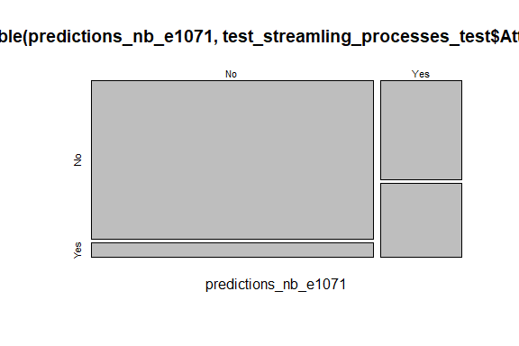

```r
plot(table(predictions_nb_e1071, test_streamling_processes_test$Attrition))
```

#### Classification: SVM with Repeated k-fold Cross Validation

```r
### 5.a. SVM Attritionifier using 5-fold cross validation with 3 reps
# We train a Support Vector Machine (for Classification) using "Churn" variable
# in the training dataset based on a repeated 5-fold cross validation train
# control with 10 reps.

# The repeated k-fold cross-validation method involves repeating the number of
# times the dataset is split into k-subsets. The final model accuracy/RMSE is
# taken as the mean from the number of repeats.

train_control_svm <- trainControl(method = "repeatedcv", number = 5, repeats = 10)

streamling_dateset_model_svm <-
  caret::train(`Attrition` ~ ., data = train_streamling_processes_train,
               trControl = train_control_svm, na.action = na.omit,
               method = "svmLinearWeights2", metric = "Accuracy")

### 5.b. Test the trained SVM model using the testing dataset
predictions_svm <- predict(streamling_dateset_model_svm, test_streamling_processes_test[, 1:31])

### 5.c. View a summary of the model and view the confusion matrix
print(streamling_dateset_model_svm)
```

```
## L2 Regularized Linear Support Vector Machines with Class Weights
##
## 1103 samples
##   30 predictor
##    2 classes: 'No', 'Yes'
##
## No pre-processing
## Resampling: Cross-Validated (5 fold, repeated 10 times)
## Summary of sample sizes: 882, 882, 882, 883, 883, 882, ...
## Resampling results across tuning parameters:
##
##   cost  Loss  weight  Accuracy   Kappa
##   0.25  L1    1       0.7316981  0.0008966698
##   0.25  L1    2       0.7498893  0.0091594654
##   0.25  L1    3       0.6940498  0.0187904658
##   0.25  L2    1       0.8386261  0.0000000000
##   0.25  L2    2       0.8386261  0.0000000000
##   0.25  L2    3       0.8348161  0.0272426179
##   0.50  L1    1       0.7314788  0.0094526012
##   0.50  L1    2       0.7113369  0.0091888134
##   0.50  L1    3       0.7560950  0.0108168897
##   0.50  L2    1       0.8386261  0.0000000000
##   0.50  L2    2       0.8386261  0.0000000000
##   0.50  L2    3       0.8348161  0.0272426179
##   1.00  L1    1       0.7801501  0.0024531820
##   1.00  L1    2       0.7121156  0.0012114600
##   1.00  L1    3       0.7351740  0.0113118554
##   1.00  L2    1       0.8386261  0.0000000000
##   1.00  L2    2       0.8386261  0.0000000000
##   1.00  L2    3       0.8348161  0.0272426179
##
## Accuracy was used to select the optimal model using the largest value.
## The final values used for the model were cost = 0.25, Loss = L2 and weight = 1.
```

```r
caret::confusionMatrix(predictions_svm, test_streamling_processes_test$Attrition)
```

```
## Confusion Matrix and Statistics
##
##           Reference
## Prediction  No Yes
##        No  308  59
##        Yes   0   0
##
##                Accuracy : 0.8392
##                  95% CI : (0.7976, 0.8753)
##     No Information Rate : 0.8392
##     P-Value [Acc > NIR] : 0.5347
##
##                   Kappa : 0
##
##  Mcnemar's Test P-Value : 4.321e-14
##
##             Sensitivity : 1.0000
##             Specificity : 0.0000
##          Pos Pred Value : 0.8392
##          Neg Pred Value :    NaN
##              Prevalence : 0.8392
##          Detection Rate : 0.8392
##    Detection Prevalence : 1.0000
##       Balanced Accuracy : 0.5000
##
##        'Positive' Class : No
##
```

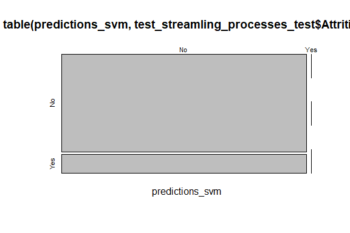

```r
plot(table(predictions_svm, test_streamling_processes_test$Attrition))
```

#### Classification: Naive Bayes with Leave One Out Cross Validation

```r
# In Leave One Out Cross-Validation (LOOCV), a data instance is left out and a
# model constructed on all other data instances in the training set. This is
# repeated for all data instances.


### 6.a. Train a Naive Bayes Attritionifier based on an LOOCV
train_control_loocv <- trainControl(method = "LOOCV")

streamling_dateset_model_nb_loocv <-
  caret::train(`Attrition` ~ ., data = train_streamling_processes_train,
               trControl = train_control_loocv, na.action = na.omit,
               method = "naive_bayes", metric = "Accuracy")

### 6.b. Test the trained model using the testing dataset
predictions_nb_loocv <-
  predict(streamling_dateset_model_nb_loocv, test_streamling_processes_test[, 1:31])

### 6.c. View the confusion matrix
print(streamling_dateset_model_nb_loocv)
```

```
## Naive Bayes
##
## 1103 samples
##   30 predictor
##    2 classes: 'No', 'Yes'
##
## No pre-processing
## Resampling: Leave-One-Out Cross-Validation
## Summary of sample sizes: 1102, 1102, 1102, 1102, 1102, 1102, ...
## Resampling results across tuning parameters:
##
##   usekernel  Accuracy   Kappa
##   FALSE      0.6681777  0.2418589
##    TRUE      0.8386219  0.0000000
##
## Tuning parameter 'laplace' was held constant at a value of 0
## Tuning
##  parameter 'adjust' was held constant at a value of 1
## Accuracy was used to select the optimal model using the largest value.
## The final values used for the model were laplace = 0, usekernel = TRUE
##  and adjust = 1.
```

```r
caret::confusionMatrix(predictions_nb_loocv, test_streamling_processes_test$Attrition)
```

```
## Confusion Matrix and Statistics
##
##           Reference
## Prediction  No Yes
##        No  308  59
##        Yes   0   0
##
##                Accuracy : 0.8392
##                  95% CI : (0.7976, 0.8753)
##     No Information Rate : 0.8392
##     P-Value [Acc > NIR] : 0.5347
##
##                   Kappa : 0
##
##  Mcnemar's Test P-Value : 4.321e-14
##
##             Sensitivity : 1.0000
##             Specificity : 0.0000
##          Pos Pred Value : 0.8392
##          Neg Pred Value :    NaN
##              Prevalence : 0.8392
##          Detection Rate : 0.8392
##    Detection Prevalence : 1.0000
##       Balanced Accuracy : 0.5000
##
##        'Positive' Class : No
##
```

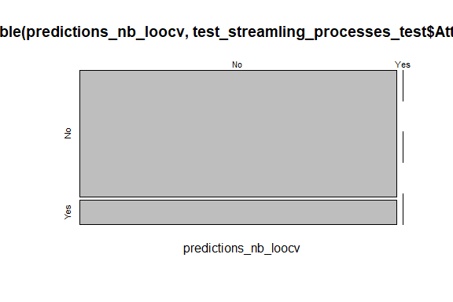

```r
plot(table(predictions_nb_loocv, test_streamling_processes_test$Attrition))
```

### Actual Our Model Algorithm

```r
### Train the model
set.seed(7)
train_control <- trainControl(method = "cv", number = 5)
streamling_caret_model_svm_radial <- # nolint: object_length_linter.
  train(Attrition ~ ., data = train_streamling_processes_train, method = "svmRadial",
        metric = "Accuracy", trControl = train_control)

#### Display the model's details
print(streamling_caret_model_svm_radial)
```

```
## Support Vector Machines with Radial Basis Function Kernel
##
## 1103 samples
##   30 predictor
##    2 classes: 'No', 'Yes'
##
## No pre-processing
## Resampling: Cross-Validated (5 fold)
## Summary of sample sizes: 882, 882, 883, 882, 883
## Resampling results across tuning parameters:
##
##   C     Accuracy   Kappa
##   0.25  0.8386261  0.00000000
##   0.50  0.8404401  0.01855692
##   1.00  0.8604072  0.23391160
##
## Tuning parameter 'sigma' was held constant at a value of 0.01332559
## Accuracy was used to select the optimal model using the largest value.
## The final values used for the model were sigma = 0.01332559 and C = 1.
```

```r
#### Make predictions
predictions <- predict(streamling_caret_model_svm_radial,
                       test_streamling_processes_test[, 1:31])

#### Display the model's evaluation metrics
table(predictions, test_streamling_processes_test$Attrition)
```

```
##
## predictions  No Yes
##         No  306  45
##         Yes   2  14
```

```r
confusion_matrix <-
  caret::confusionMatrix(predictions,
                         test_streamling_processes_test[, 1:31]$Attrition)
print(confusion_matrix)
```

```
## Confusion Matrix and Statistics
##
##           Reference
## Prediction  No Yes
##        No  306  45
##        Yes   2  14
##
##                Accuracy : 0.8719
##                  95% CI : (0.8334, 0.9044)
##     No Information Rate : 0.8392
##     P-Value [Acc > NIR] : 0.04801
##
##                   Kappa : 0.3272
##
##  Mcnemar's Test P-Value : 8.993e-10
##
##             Sensitivity : 0.9935
##             Specificity : 0.2373
##          Pos Pred Value : 0.8718
##          Neg Pred Value : 0.8750
##              Prevalence : 0.8392
##          Detection Rate : 0.8338
##    Detection Prevalence : 0.9564
##       Balanced Accuracy : 0.6154
##
##        'Positive' Class : No
##
```

[figure not shown]

```r
# Load required libraries
library(ggplot2)

# Convert the confusion matrix to a data frame
conf_matrix_df <- as.data.frame(as.table(confusion_matrix$table))

# Rename columns for clarity
names(conf_matrix_df) <- c("Reference", "Prediction", "Frequency")

# Plot the confusion matrix as a heatmap
ggplot(data = conf_matrix_df, aes(x = Reference, y = Prediction, fill = Frequency)) +
  geom_tile() +
  geom_text(aes(label = Frequency)) +
  scale_fill_gradient(low = "white", high = "blue") +
  labs(title = "Confusion Matrix") +
  theme_minimal()
```

## Model Performance and Comparison

The code performs model training and comparison for predicting ‘Attrition’ using different algorithms. It sets up a repeated cross-validation control (train_control), then trains models using Linear Discriminant Analysis (LDA), Classification and Regression Trees (CART), k-Nearest Neighbors (KNN), Support Vector Machine with radial kernel (SVM), and Random Forest. The goal is to evaluate and compare the performance of these models using the specified training control settings.

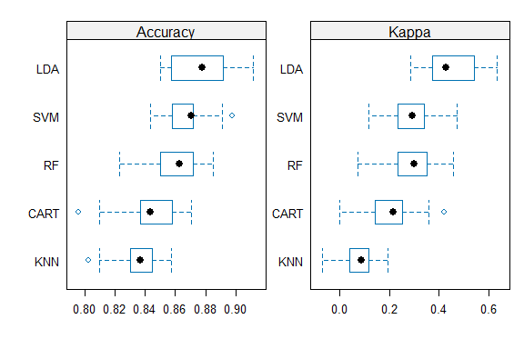

```r
train_control <- trainControl(method = "repeatedcv", number = 10, repeats = 3)

### LDA
set.seed(7)
streamling_model_lda <- train(Attrition ~ ., data = STREAMLINING_PROCESSES_AT_KINYANJUI_FARM,
                            method = "lda", trControl = train_control)

### CART
set.seed(7)
streamling_model_cart <- train(Attrition ~ ., data = STREAMLINING_PROCESSES_AT_KINYANJUI_FARM,
                             method = "rpart", trControl = train_control)

### KNN
set.seed(7)
streamling_model_knn <- train(Attrition ~ ., data = STREAMLINING_PROCESSES_AT_KINYANJUI_FARM,
                            method = "knn", trControl = train_control)

### SVM
set.seed(7)
streamling_model_svm <- train(Attrition ~ ., data = STREAMLINING_PROCESSES_AT_KINYANJUI_FARM,
                            method = "svmRadial", trControl = train_control)

### Random Forest
set.seed(7)
streamling_model_rf <- train(Attrition ~ ., data = STREAMLINING_PROCESSES_AT_KINYANJUI_FARM,
                           method = "rf", trControl = train_control)

## 3.b. Call the `resamples` Function
# We then create a list of the model results and pass the list as an argument
# to the `resamples` function.

results <- resamples(list(LDA = streamling_model_lda, CART = streamling_model_cart,
                          KNN = streamling_model_knn, SVM = streamling_model_svm,
                          RF = streamling_model_rf))

scales <- list(x = list(relation = "free"), y = list(relation = "free"))
bwplot(results, scales = scales)
```

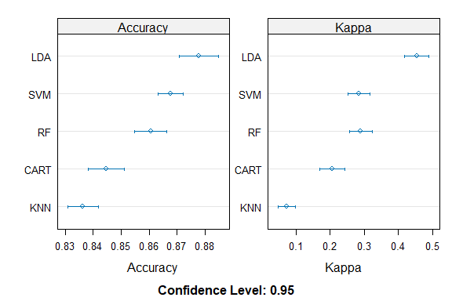

```r
scales <- list(x = list(relation = "free"), y = list(relation = "free"))
dotplot(results, scales = scales)
```

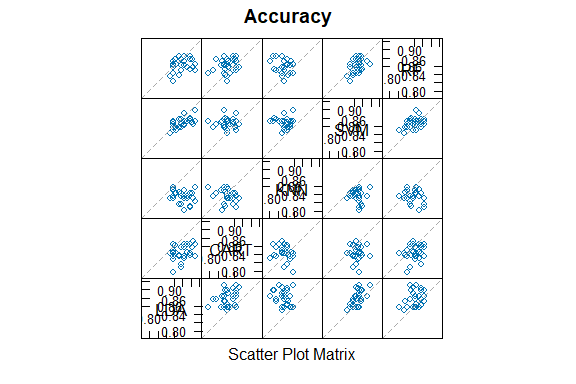

```r
splom(results)
```

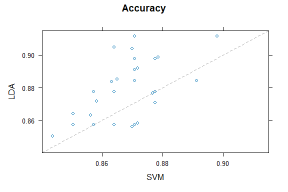

```r
# xyplot plots to compare models
xyplot(results, models = c("LDA", "SVM"))
```

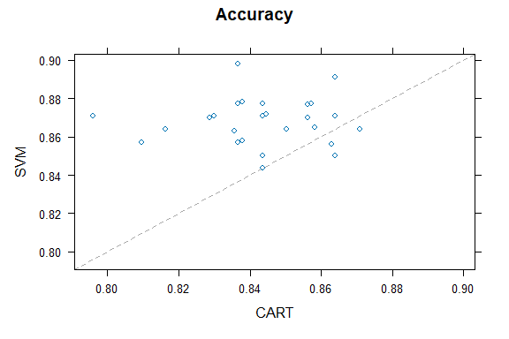

```r
# or
# xyplot plots to compare models
xyplot(results, models = c("SVM", "CART"))
```

```r
diffs <- diff(results)

summary(diffs)
```

```
##
## Call:
## summary.diff.resamples(object = diffs)
##
## p-value adjustment: bonferroni
## Upper diagonal: estimates of the difference
## Lower diagonal: p-value for H0: difference = 0
##
## Accuracy
##      LDA       CART      KNN       SVM       RF
## LDA             0.033098  0.041479  0.010201  0.017220
## CART 2.309e-08            0.008381 -0.022897 -0.015878
## KNN  2.859e-08 0.836319            -0.031278 -0.024259
## SVM  0.011950  1.216e-05 7.210e-09            0.007019
## RF   0.000505  0.002636  1.744e-05 0.178204
##
## Kappa
##      LDA       CART      KNN       SVM       RF
## LDA             0.247718  0.380570  0.169228  0.163456
## CART 4.288e-13            0.132852 -0.078490 -0.084262
## KNN  2.745e-15 3.032e-05           -0.211342 -0.217114
## SVM  4.027e-11 0.010489  6.963e-10           -0.005772
## RF   4.040e-09 0.004762  2.889e-10 1.000000
```

# Hyper Parameter Tunning

#### Grid Search

```r
# Apply a "Grid Search" to identify the best parameter value
# Each axis of the grid is an algorithm parameter, and points on the grid are
# specific combinations of parameters.

seed <- 7
metric <- "Accuracy"
train_control <- trainControl(method = "repeatedcv", number = 10, repeats = 3,
                              search = "grid")
set.seed(seed)

getModelInfo("RRFglobal")
```

```
## $RRFglobal
## $RRFglobal$label
## [1] "Regularized Random Forest"
##
## $RRFglobal$library
## [1] "RRF"
##
## $RRFglobal$loop
## NULL
##
## $RRFglobal$type
## [1] "Regression"     "Classification"
##
## $RRFglobal$parameters
##   parameter   class                         label
## 1      mtry numeric #Randomly Selected Predictors
## 2   coefReg numeric          Regularization Value
##
## $RRFglobal$grid
## function (x, y, len = NULL, search = "grid")
## {
##     if (search == "grid") {
##         out <- expand.grid(mtry = caret::var_seq(p = ncol(x),
##             classification = is.factor(y), len = len), coefReg = seq(0.01,
##             1, length = len))
##     }
##     else {
##         out <- data.frame(mtry = sample(1:ncol(x), size = len,
##             replace = TRUE), coefReg = runif(len, min = 0, max = 1))
##     }
##     out
## }
##
## $RRFglobal$fit
## function (x, y, wts, param, lev, last, classProbs, ...)
## {
##     RRF::RRF(x, y, mtry = param$mtry, coefReg = param$coefReg,
##         ...)
## }
##
```

[output cut: 28 more lines]

```
##     out
## }
##
## $RRFglobal$levels
## function (x)
## x$obsLevels
##
## $RRFglobal$tags
## [1] "Random Forest"              "Ensemble Model"
## [3] "Bagging"                    "Implicit Feature Selection"
## [5] "Regularization"
##
## $RRFglobal$sort
## function (x)
## x[order(x$coefReg), ]
```

```r
# The Regularized Random Forest algorithm exposes the "coefReg" parameter
# in addition to the "mtry" parameter for tuning.
## The "mtry" parameter
# Number of variables randomly sampled as candidates at each split.

## The "coefReg" parameter
# It stands for coefficient(s) of regularization.
# A smaller coefficient may lead to a smaller feature subset, i.e.,
# there are fewer variables with non-zero importance scores. coefReg must be
# either a single value (all variables have the same coefficient) or a numeric
# vector of length equal to the number of predictor variables. default: 0.8

tunegrid <- expand.grid(.mtry = c(1:10),
                        .coefReg = seq(from = 0.1, to = 1, by = 0.1))

streamling_model_grid_search_rrf_global <- train(Attrition ~ ., data = STREAMLINING_PROCESSES_AT_KINYANJUI_FARM, # nolint
                                            method = "RRFglobal",
                                            metric = metric,
                                            tuneGrid = tunegrid,
                                            trControl = train_control)
print(streamling_model_grid_search_rrf_global)
```

```
## Regularized Random Forest
##
## 1470 samples
##   30 predictor
##    2 classes: 'No', 'Yes'
##
## No pre-processing
## Resampling: Cross-Validated (10 fold, repeated 3 times)
## Summary of sample sizes: 1323, 1323, 1322, 1323, 1323, 1323, ...
## Resampling results across tuning parameters:
##
##   mtry  coefReg  Accuracy   Kappa
##    1    0.1      0.8206506  0.1595824
##    1    0.2      0.8195215  0.1126055
##    1    0.3      0.8176812  0.1142811
```

[output cut: 100 more lines]

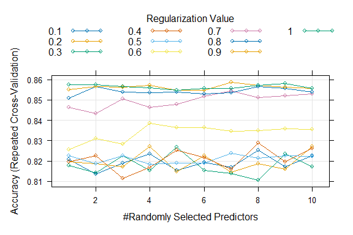

```r
plot(streamling_model_grid_search_rrf_global)
```

# Ensemble methods

`Ensemble methods` combine multiple machine learning models to improve overall predictive performance and robustness. These methods leverage the strengths of different models to compensate for individual weaknesses. Common ensemble methods include bagging, boosting, and stacking. `Bagging (Random Forest)` builds multiple models in parallel and averages their predictions, reducing variance. `Boosting (AdaBoost)` focuses on sequentially improving model performance by giving more weight to missclassified instances. Stacking combines predictions from multiple models using another model as a meta-learner. Ensemble methods often outperform individual models, providing more reliable and accurate predictions.

### Boosting

#### GBM

```r
seed <- 7
metric <- "Accuracy"
train_control <- trainControl(method = "cv", number = 5)


#### Boosting with C5.0 ----
# C5.0
set.seed(seed)
ion_model_c50 <- train(Attrition ~ ., data = STREAMLINING_PROCESSES_AT_KINYANJUI_FARM, method = "C5.0",
                       metric = metric,
                       trControl = train_control)

####  Boosting with Stochastic Gradient Boosting ----
set.seed(seed)
ion_model_gbm <- train(Attrition ~ ., data = STREAMLINING_PROCESSES_AT_KINYANJUI_FARM, method = "gbm",
                       metric = metric, trControl = train_control,
                       verbose = FALSE)

# Summarize results
boosting_results <-
  resamples(list("C5.0 boosting ensemble" =ion_model_c50,
                 "Generalized Boosted Regression Modeling (GBM)" = ion_model_gbm))

summary(boosting_results)
```

```
##
## Call:
## summary.resamples(object = boosting_results)
##
## Models: C5.0 boosting ensemble, Generalized Boosted Regression Modeling (GBM)
## Number of resamples: 5
##
## Accuracy
##                                                    Min.   1st Qu.    Median
## C5.0 boosting ensemble                        0.8474576 0.8508475 0.8639456
## Generalized Boosted Regression Modeling (GBM) 0.8474576 0.8600683 0.8779661
##                                                    Mean   3rd Qu.     Max. NA's
## C5.0 boosting ensemble                        0.8639860 0.8737201 0.883959    0
## Generalized Boosted Regression Modeling (GBM) 0.8721261 0.8843537 0.890785    0
##
## Kappa
##                                                    Min.   1st Qu.   Median
## C5.0 boosting ensemble                        0.2432879 0.3606016 0.379719
## Generalized Boosted Regression Modeling (GBM) 0.2600747 0.3077278 0.461788
##                                                    Mean   3rd Qu.      Max.
## C5.0 boosting ensemble                        0.3633392 0.3880737 0.4450139
## Generalized Boosted Regression Modeling (GBM) 0.3950538 0.4658159 0.4798626
##                                               NA's
## C5.0 boosting ensemble                           0
## Generalized Boosted Regression Modeling (GBM)    0
```

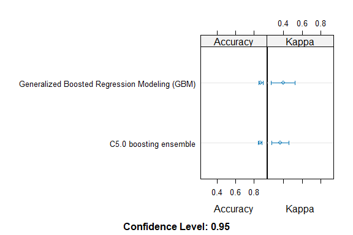

```r
dotplot(boosting_results)
```

# Save and Load your Model

```r
# Saving a model into a file allows you to load it later and use it to make
# predictions. Saved models can be loaded by calling the `readRDS()` function

saveRDS(streamling_caret_model_svm_radial, "./models/saved_streamling_caret_model_svm_radial.rds")
# The saved model can then be loaded later as follows:
loaded_streamling_model_svm <- readRDS("./models/saved_streamling_caret_model_svm_radial.rds")
print(loaded_streamling_model_svm)
```

```
## Support Vector Machines with Radial Basis Function Kernel
##
## 1103 samples
##   30 predictor
##    2 classes: 'No', 'Yes'
##
## No pre-processing
## Resampling: Cross-Validated (5 fold)
## Summary of sample sizes: 882, 882, 883, 882, 883
## Resampling results across tuning parameters:
##
##   C     Accuracy   Kappa
##   0.25  0.8386261  0.00000000
##   0.50  0.8404401  0.01855692
##   1.00  0.8604072  0.23391160
##
## Tuning parameter 'sigma' was held constant at a value of 0.01332559
## Accuracy was used to select the optimal model using the largest value.
## The final values used for the model were sigma = 0.01332559 and C = 1.
```

```r
predictions_with_loaded_model <-
  predict(loaded_streamling_model_svm, newdata = test_streamling_processes_test)
confusionMatrix(predictions_with_loaded_model, test_streamling_processes_test$Attrition)
```

```
## Confusion Matrix and Statistics
##
##           Reference
## Prediction  No Yes
##        No  306  45
##        Yes   2  14
##
##                Accuracy : 0.8719
##                  95% CI : (0.8334, 0.9044)
##     No Information Rate : 0.8392
##     P-Value [Acc > NIR] : 0.04801
##
##                   Kappa : 0.3272
##
##  Mcnemar's Test P-Value : 8.993e-10
##
##             Sensitivity : 0.9935
##             Specificity : 0.2373
##          Pos Pred Value : 0.8718
##          Neg Pred Value : 0.8750
##              Prevalence : 0.8392
##          Detection Rate : 0.8338
##    Detection Prevalence : 0.9564
##       Balanced Accuracy : 0.6154
##
##        'Positive' Class : No
##
```

#### Making prediction with the model

```r
to_be_predicted <-
  data.frame(
  Age = 41,
  BusinessTravel = "Travel_Rarely",
  DailyRate = 1102,
  Department = "Sales",
  DistanceFromHome = 1,
  Education = 2,
  EducationField = "Life Sciences",
  EnvironmentSatisfaction = 2,
  Gender = "Female",
  HourlyRate = 94,
  JobInvolvement = 3,
  JobLevel = 2,
  JobRole = "Sales Executive",
  JobSatisfaction = 4,
  MaritalStatus = "Single",
  MonthlyIncome = 5993,
  MonthlyRate = 19479,
  NumCompaniesWorked = 8,
  OverTime = "Yes",
  PercentSalaryHike = 11,
  PerformanceRating = 3,
  RelationshipSatisfaction = 1,
  StockOptionLevel = 0,
  TotalWorkingYears = 8,
  TrainingTimesLastYear = 0,
  WorkLifeBalance = 1,
  YearsAtCompany = 6,
  YearsInCurrentRole = 4,
  YearsSinceLastPromotion = 0,
  YearsWithCurrManager = 5
)

predict(loaded_streamling_model_svm, to_be_predicted)
```

```
## [1] No
## Levels: No Yes
```

#### Make predictions using the model through a function

```r
predict_attrition <-
  function(arg_Age, arg_BusinessTravel, arg_DailyRate,
           arg_Department, arg_DistanceFromHome, arg_Education, arg_EducationField,
           arg_EnvironmentSatisfaction, arg_Gender,
           arg_HourlyRate, arg_JobInvolvement, arg_JobLevel, arg_JobRole,
           arg_JobSatisfaction, arg_MaritalStatus, arg_MonthlyIncome, arg_MonthlyRate,
           arg_NumCompaniesWorked, arg_OverTime, arg_PercentSalaryHike,
           arg_PerformanceRating, arg_RelationshipSatisfaction, arg_StockOptionLevel,
           arg_TotalWorkingYears, arg_TrainingTimesLastYear, arg_WorkLifeBalance, arg_YearsAtCompany,
           arg_YearsInCurrentRole, arg_YearsSinceLastPromotion, arg_YearsWithCurrManager) {

    # Create a data frame using the arguments
    to_be_predicted <- data.frame(Age = arg_Age,
                                  BusinessTravel = arg_BusinessTravel, DailyRate = arg_DailyRate,
                                  Department = arg_Department, DistanceFromHome = arg_DistanceFromHome,
                                  Education = arg_Education, EducationField = arg_EducationField,
                                  EnvironmentSatisfaction = arg_EnvironmentSatisfaction, Gender = arg_Gender,
                                  HourlyRate = arg_HourlyRate, JobInvolvement = arg_JobInvolvement,
                                  JobLevel = arg_JobLevel, JobRole = arg_JobRole,
                                  JobSatisfaction = arg_JobSatisfaction, MaritalStatus = arg_MaritalStatus,
                                  MonthlyIncome = arg_MonthlyIncome, MonthlyRate = arg_MonthlyRate,
                                  NumCompaniesWorked = arg_NumCompaniesWorked,
                                  OverTime = arg_OverTime, PercentSalaryHike = arg_PercentSalaryHike,
                                  PerformanceRating = arg_PerformanceRating,
                                  RelationshipSatisfaction = arg_RelationshipSatisfaction,
                                  StockOptionLevel = arg_StockOptionLevel,
                                  TotalWorkingYears = arg_TotalWorkingYears,
                                  TrainingTimesLastYear = arg_TrainingTimesLastYear,
                                  WorkLifeBalance = arg_WorkLifeBalance, YearsAtCompany = arg_YearsAtCompany,
                                  YearsInCurrentRole = arg_YearsInCurrentRole,
                                  YearsSinceLastPromotion = arg_YearsSinceLastPromotion,
                                  YearsWithCurrManager = arg_YearsWithCurrManager)

    # Make a prediction based on the data frame
    predict(loaded_streamling_model_svm, to_be_predicted)
  }
predict_attrition(41,
                 "Travel_Rarely",
                 1102,
                 "Sales",
                 1,
                 2,
                "Life Sciences",
                 2,
                 "Female",
                 94,
                 3,
                 2,
                 "Sales Executive",
                 4,
                 "Single",
                 5993,
                 19479,
                 8,
                 "Yes",
                 11,
                 3,
                 1,
                 0,
                 8,
                 0,
                 1,
                 6,
                 4,
                 0,
                 5)
```

```
## [1] No
## Levels: No Yes
```

# Plumber API

Plumber API in R facilitates the creation of web APIs, enabling seamless integration of R code for data processing and analysis. It transforms R scripts into interactive and accessible web services, enhancing collaboration and data-driven decision-making.

```r
if (!requireNamespace("future", quietly = TRUE)) install.packages("future")

library(future)
# Define a function to start the Plumber API in a separate process
start_api <- function() {
  api <- plumber::plumb("PlumberAPI.R")
  api$run(host = "127.0.0.1", port = 5022, swagger = TRUE)
}

# Start the API in a separate process
future::plan("multisession")  # Use multisession backend for parallel processing
future({
  start_api()
})
```

```
## MultisessionFuture:
## Label: '<none>'
## Expression:
## {
##     start_api()
## }
## Lazy evaluation: FALSE
## Asynchronous evaluation: TRUE
## Local evaluation: TRUE
## Environment: R_GlobalEnv
## Capture standard output: TRUE
## Capture condition classes: 'condition' (excluding 'nothing')
## Globals: 1 objects totaling 6.65 KiB (function 'start_api' of 6.65 KiB)
## Packages: <none>
## L'Ecuyer-CMRG RNG seed: <none> (seed = FALSE)
## Resolved: FALSE
## Value: <not collected>
## Conditions captured: <none>
## Early signaling: FALSE
## Owner process: 1f35b32c-3fd8-aa67-1a03-364646a4c6ac
## Class: 'MultisessionFuture', 'ClusterFuture', 'MultiprocessFuture', 'Future', 'environment'
```

```r
### Generate the URL required to access the API ----

# We set this as a constant port 5022 running on localhost
base_url <- "http://127.0.0.1:5022/Attrition"

params <- data.frame(
  arg_Age = 41,
  arg_BusinessTravel = "Travel_Rarely",
  arg_DailyRate = 1102,
  arg_Department = "Sales",
  arg_DistanceFromHome = 1,
  arg_Education = 2,
  arg_EducationField = "Life Sciences",
  arg_EnvironmentSatisfaction = 2,
  arg_Gender = "Female",
  arg_HourlyRate = 94,
  arg_JobInvolvement = 3,
  arg_JobLevel = 2,
  arg_JobRole = "Sales Executive",
  arg_JobSatisfaction = 4,
  arg_MaritalStatus = "Single",
  arg_MonthlyIncome = 5993,
  arg_MonthlyRate = 19479,
  arg_NumCompaniesWorked = 8,
  arg_OverTime = "Yes",
  arg_PercentSalaryHike = 11,
  arg_PerformanceRating = 3,
  arg_RelationshipSatisfaction = 1,
  arg_StockOptionLevel = 0,
  arg_TotalWorkingYears = 8,
  arg_TrainingTimesLastYear = 0,
  arg_WorkLifeBalance = 1,
  arg_YearsAtCompany = 6,
  arg_YearsInCurrentRole = 4,
  arg_YearsSinceLastPromotion = 0,
  arg_YearsWithCurrManager = 5
)



query_url <- httr::modify_url(url = base_url, query = params)
print(query_url)
```

[output not shown]

```r
Sys.sleep(10)
model_prediction <- GET(query_url)
content(model_prediction)
```

```
## [[1]]
## [1] "No"
```

```r
content(model_prediction)[[1]]
```

```
## [1] "No"
```

```r
# Parse the response into the right format
model_prediction_raw <- content(model_prediction, as = "text",
                                encoding = "utf-8")
jsonlite::fromJSON(model_prediction_raw)
```

```
## [1] "No"
```

```r
get_attrition_predictions <-
  function(arg_Age, arg_BusinessTravel, arg_DailyRate,
           arg_Department, arg_DistanceFromHome, arg_Education, arg_EducationField,
           arg_EnvironmentSatisfaction, arg_Gender,
           arg_HourlyRate, arg_JobInvolvement, arg_JobLevel, arg_JobRole,
           arg_JobSatisfaction, arg_MaritalStatus, arg_MonthlyIncome, arg_MonthlyRate,
           arg_NumCompaniesWorked, arg_OverTime, arg_PercentSalaryHike,
           arg_PerformanceRating, arg_RelationshipSatisfaction, arg_StockOptionLevel,
           arg_TotalWorkingYears, arg_TrainingTimesLastYear, arg_WorkLifeBalance, arg_YearsAtCompany,
           arg_YearsInCurrentRole, arg_YearsSinceLastPromotion, arg_YearsWithCurrManager) {

    base_url <- "http://127.0.0.1:5022/Attrition"

    params <- list(
      arg_Age = arg_Age,
      arg_BusinessTravel = arg_BusinessTravel,
      arg_DailyRate = arg_DailyRate,
      arg_Department = arg_Department,
      arg_DistanceFromHome = arg_DistanceFromHome,
      arg_Education = arg_Education,
      arg_EducationField = arg_EducationField,
      arg_EnvironmentSatisfaction = arg_EnvironmentSatisfaction,
      arg_Gender = arg_Gender,
      arg_HourlyRate = arg_HourlyRate,
      arg_JobInvolvement = arg_JobInvolvement,
      arg_JobLevel = arg_JobLevel,
      arg_JobRole = arg_JobRole,
      arg_JobSatisfaction = arg_JobSatisfaction,
      arg_MaritalStatus = arg_MaritalStatus,
      arg_MonthlyIncome = arg_MonthlyIncome,
      arg_MonthlyRate = arg_MonthlyRate,
      arg_NumCompaniesWorked = arg_NumCompaniesWorked,
      arg_OverTime = arg_OverTime,
      arg_PercentSalaryHike = arg_PercentSalaryHike,
      arg_PerformanceRating = arg_PerformanceRating,
      arg_RelationshipSatisfaction = arg_RelationshipSatisfaction,
      arg_StockOptionLevel = arg_StockOptionLevel,
      arg_TotalWorkingYears = arg_TotalWorkingYears,
      arg_TrainingTimesLastYear = arg_TrainingTimesLastYear,
      arg_WorkLifeBalance = arg_WorkLifeBalance,
      arg_YearsAtCompany = arg_YearsAtCompany,
      arg_YearsInCurrentRole = arg_YearsInCurrentRole,
      arg_YearsSinceLastPromotion = arg_YearsSinceLastPromotion,
      arg_YearsWithCurrManager = arg_YearsWithCurrManager
    )


    query_url <- modify_url(url = base_url, query = params)

    model_prediction <- GET(query_url)

    model_prediction_raw <- content(model_prediction, as = "text",
                                    encoding = "utf-8")

    jsonlite::fromJSON(model_prediction_raw)
  }

get_attrition_predictions(41,
                  "Travel_Rarely",
                  1102,
                  "Sales",
                  1,
                  2,
                  "Life Sciences",
                  2,
                  "Female",
                  94,
                  3,
                  2,
                  "Sales Executive",
                  4,
                  "Single",
                  5993,
                  19479,
                  8,
                  "Yes",
                  11,
                  3,
                  1,
                  0,
                  8,
                  0,
                  1,
                  6,
                  4,
                  0,
                  5)
```

```
## [1] "No"
```

# Prediction Web Form And Customer-facing Dashboard

The customer facing dashboard is on real-time bases where it visualizes the customer data verses other customer data to show the goal to be attained or to guide for future decisions making.`NB` since the file is to large can be opened when downloaded `.html` and viewed via the Browser

```r
cat('<iframe src="http://localhost/Good%20Architecture/Attrition%20Prediction.php" width="1000" height="800"></iframe>')
```

[interactive chart not shown]